💻

# Lecture 4: Comparing Two Groups I

| Dates | @October 21, 2021 |
| --- | --- |
| Type | 📒 Lesson |
| Topic | Hypothesis testsIntroduction to R |
| Link | https://keats.kcl.ac.uk/mod/kalvidres/view.php?id=5717007 |

#### 📂 Files

| RMarkdown file | Dataset |
| --- | --- |
| https://raw.githubusercontent.com/fans-stats/intro_to_R_stats/main/lecture_4/lecture_4.Rmd | https://github.com/fans-stats/intro_to_R_stats/blob/main/datasets/children_nutrition.SAV?raw=true |

# Summary of session

- Review of function concepts
- Loading SPSS files
- Data summaries
- Two-sample t-test
- Levene's test
- McNemar's test

# **About functions**

Before looking into this week’s practical data we should discuss a very important concept for our future analyses - the function. A function is mathematical element that receives an numerical input and return a different one, e.g., $f(x) = x + 1 \rightarrow f(1) = 2$.

In R functions are a somewhat more generic concept that receives not only numbers but also a plethora of different elements, such as vector, matrices, and tibbles (dataframes). They also do not necessarily return an output. An example is the *is.na()* function that checks whether an entry is a ‘not-a-number’.

```
is.na(NA)
```

```
## [1] TRUE
```

```
is.na('Test')
```

```
## [1] FALSE
```

```
is.na(1)
```

```
## [1] FALSE
```

R has several built-in functions and such capabilities can be expanded by downloading packages - or else we can create our own function! A function in R has the following structure:

```
function_name <-function(input){

# Some operation

}
```

And for our initial function example, one could write it as follows:

```
xplus1 <-function(x){

  xp <- x + 1

return(xp)

}
```

```
xplus1(1)
```

```
## [1] 2
```

Now we shall see how we can use functions in the context of our work.

# **Background:**

The data set consists of a sample of *n = 500* school children. A research team was interested in measuring the average height of children leaving in an urban area and children leaving in a rural area. In the dataset you will find the following variables:

- **ethnicity**: children’s ethnicity (1: White, 2: Black, 3: Asian, 4: Other)
- **area**: classification of the area the children live in (1: Rural and 0: Urban)
- **Height2014**: children’s height as measured in 2014.
- **Height2018**: children’s height as measured in 2018.
- **nutrition2014**: a classification of the quality of children’s nutrition by the research team (based on appropriate parameters, interviews and observation) made in 2014 (1: bad, 2: average, 3: good).
- **nutrition2018**: a classification of the quality of children’s nutrition by the research team (based on appropriate parameters, interviews and observation) made in 2018 (1: bad, 2: average, 3: good).

# **Loading Packages**

```
library(foreign)
library(tidyverse)
library(car) # Remember to install the package 'car' if you do not have it yet!
library(gmodels) # Also install the package 'gmodels' if you do not have it!
```

# **Loading data**

```
url <- 'https://github.com/fans-stats/intro_to_R_stats/blob/main/datasets/children_nutrition.SAV?raw=true'
dataset <- read.spss(file = url, to.data.frame = TRUE)
dataset <- as_tibble(dataset)
dataset
```

| Title | Ethnicity<fct> | Area<fct> | Height2014<dbl> | Height2018<dbl> | Nutrition2014<fct> | Nutrition2018<fct> |
| --- | --- | --- | --- | --- | --- | --- |
| Untitled | Black | Urban | 142.9692 | 169.5925 | average | average |
| Untitled | White | Urban | 143.9117 | 168.7686 | average | poor |
| Untitled | White | Urban | 142.4813 | 168.6906 | average | poor |
| Untitled | White | Urban | 145.2158 | 171.9558 | average | poor |
| Untitled | Black | Urban | 142.0239 | 167.9717 | poor | average |
| Untitled | White | Urban | 141.7364 | 169.8908 | good | average |
| Untitled | Asian | Urban | 145.0875 | 167.3013 | good | average |
| Untitled | Black | Urban | 145.3811 | 169.4299 | average | good |
| Untitled | Black | Urban | 145.0736 | 170.9094 | average | average |
| Untitled | Black | Urban | 145.0761 | 168.5953 | good | average |

# **Task 1**

First, identify the type of each variable in the dataset.

ethnicity is a categorical nominal variable

area is a categorical nominal (binary) variable

height2014 is a numerical continuous variable

height2018 is a numerical continuous variable

nutrition2014 is a categorical ordinal variable

nutrition2018 is a categorical ordinal variable

# **Task 2**

Fill in the blanks to appropriately describe the data.

```
#install.packages("psych")
library(psych)
```

```
summary(dataset)
```

```
##  Ethnicity      Area       Height2014      Height2018    Nutrition2014
##  White:225   Urban:236   Min.   :139.5   Min.   :155.1   poor   :105
##  Black:129   Rural:264   1st Qu.:144.4   1st Qu.:169.6   average:249
##  Asian:103               Median :146.0   Median :171.8   good   :146
##  Other: 43               Mean   :146.0   Mean   :173.6
##                          3rd Qu.:147.5   3rd Qu.:177.6
##                          Max.   :151.5   Max.   :194.6
##  Nutrition2018
##  poor   :158
##  average:240
##  good   :102
##
##
##
```

```
describe.by(dataset, group = dataset$Area)
```

```
##
##  Descriptive statistics by group
## group: Urban
##                vars   n   mean   sd median trimmed  mad    min    max range
## Ethnicity*        1 236   1.96 1.01   2.00    1.83 1.48   1.00   4.00  3.00
## Area*             2 236   1.00 0.00   1.00    1.00 0.00   1.00   1.00  0.00
## Height2014        3 236 144.78 1.96 144.85  144.75 1.99 139.54 149.75 10.21
## Height2018        4 236 170.00 1.92 170.00  169.96 1.85 164.56 175.97 11.41
## Nutrition2014*    5 236   2.10 0.71   2.00    2.12 1.48   1.00   3.00  2.00
## Nutrition2018*    6 236   1.90 0.69   2.00    1.88 0.00   1.00   3.00  2.00
##                 skew kurtosis   se
## Ethnicity*      0.64    -0.82 0.07
## Area*            NaN      NaN 0.00
## Height2014      0.11    -0.26 0.13
## Height2018      0.18     0.26 0.13
## Nutrition2014* -0.14    -1.03 0.05
## Nutrition2018*  0.13    -0.89 0.04
## ------------------------------------------------------------
## group: Rural
##                vars   n   mean   sd median trimmed  mad    min    max range
## Ethnicity*        1 264   1.90 0.99   2.00    1.78 1.48   1.00   4.00  3.00
## Area*             2 264   2.00 0.00   2.00    2.00 0.00   2.00   2.00  0.00
## Height2014        3 264 147.04 1.89 147.00  147.06 1.75 142.05 151.47  9.42
## Height2018        4 264 176.87 5.83 177.06  176.94 5.85 155.07 194.62 39.55
## Nutrition2014*    5 264   2.07 0.70   2.00    2.08 0.00   1.00   3.00  2.00
## Nutrition2018*    6 264   1.88 0.74   2.00    1.84 1.48   1.00   3.00  2.00
##                 skew kurtosis   se
## Ethnicity*      0.68    -0.79 0.06
## Area*            NaN      NaN 0.00
## Height2014     -0.11    -0.15 0.12
## Height2018     -0.19     0.49 0.36
## Nutrition2014* -0.09    -0.97 0.04
## Nutrition2018*  0.20    -1.15 0.05
```

In the sample, there are 225 (45.0%) white students, 129 (25.8%) black students, 103 (20.6%) Asian students, and 43 (8.6%) students of other ethnicities. With respect to area, 236 (47.2%) live in urban areas and 264 (52.8%) students live in rural areas.

Regarding the students’ height in 2014, the scores were normally distributed with mean height = 146.0 cm (SD = 2.2). Regarding the students’ height in 2018, the distribution was positively skewed, with median = 171.8 cm (min= 155.1 , max= 194.6).

With respect to the quality of the children’s nutrition, 105 (21.0%) were considered as having poor quality nutrition in 2014 and 158 ( 31.6 %) in 2018.

# **Task 3**

The researcher hypothesised that the students’ height in 2014 was 150 cm. Use the appropriate commands to test the researcher’s hypothesis. Write the null and the alternative hypotheses and report on the results.

$H_0$: the mean height in 2014 equals 150cm.

$H_\alpha$: the mean height in 2014 is different to 150cm.

```
t.test(dataset$Height2014, mu = 150)
```

```
##
##  One Sample t-test
##
## data:  dataset$Height2014
## t = -40.402, df = 499, p-value < 2.2e-16
## alternative hypothesis: true mean is not equal to 150
## 95 percent confidence interval:
##  145.7773 146.1689
## sample estimates:
## mean of x
##  145.9731
```

The mean height of the students in 2014 was 146.0 cm. This was significantly lower than 150cm (t=-40.402, df=499, p<0.001; 95% CI: 145.7773, 146.1689). Therefore, we reject the null hypothesis and infer that the students in 2014 were shorter than 150cm.

⚠️

Please note that R and SPSS show CI in a different way.

# Task 4

Use the appropriate test to see if there is a statistically significant difference in height between rural and urban areas in 2014. Write the null and the alternative hypotheses and report on the results.

First, we need to check the distribution of the variable Height2014 in each area group (rural and urban) separately by creating a histogram for ‘Height2014’.

```
ggplot(data = dataset,
       aes(x = Height2014)) +# We just need the arg x for the function aes() and histograms
    geom_histogram(aes(fill = Area)) +# This line tells ggplot what king of graph we need. Also note that the function geom_histogram() also receive a function aes().
    theme_bw()# Changing the theme for some nicer looks
```

[figure not shown]

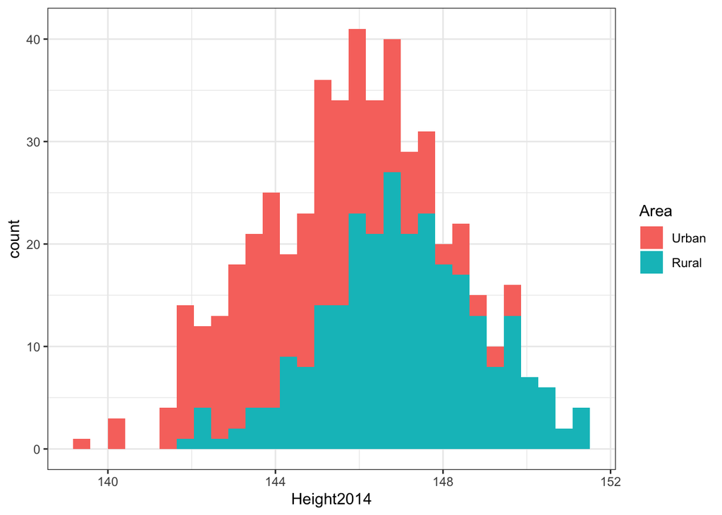

The histograms are (more or less) normally distributed. Therefore, we should use an independent samples t-test.

$H_0$: mean height 2014 in urban areas $=$ mean height 2014 in rural areas

$H_\alpha$: mean height 2014 in urban areas $\neq$ mean height 2014 in rural areas

```
# We are first going to compute Levene's test

leveneTest(Height2014 ~ Area, data = dataset, center = mean)
```

| Property | Df<int> | F value<dbl> | Pr(>F)<dbl> |
| --- | --- | --- | --- |
| group | 1 | 0.8378557 | 0.3604538 |
| Untitled | 498 | *NA* | *NA* |

```
leveneTest(Height2014 ~ Area, data = dataset, center = mean)

# Now let's discuss the arguments of the function t.test# 'Height2014 ~ Area' indicates how R is going to split the data. Here we are looking at different height measures sampled (Height2014) according to two different areas (Area). We are going to discuss formulas in more detail later - on the linear models lecture.# 'data = dataset' works as data input to the function.# 'center = mean' indicates what kind of Levene's test we are performing. We chose mean as we are using it for a t.test - which is a test of means. Another option could be median
```

| Property | Df<int> | F value<dbl> | Pr(>F)<dbl> |
| --- | --- | --- | --- |
| group | 1 | 0.8378557 | 0.3604538 |
| Untitled | 498 | *NA* | *NA* |

The Levene’s test outcome suggests that there IS NOT statistically significant difference between the variances of both distributions. Hence we can perform an independent samples t-test considering that aspect.

```
# We are now going to perform an independent samples t-test. There are a few different ways to do this. The simplest is probably as follows:

t.test(formula =Height2014 ~ Area, data = dataset, var.equal = TRUE)

# Now let's discuss the arguments of the function t.test# 'formula = Height2014 ~ Area' indicates how R is going to split the data. Here we are looking at different height measures sampled (Height2014) according to two different areas (Area). We are going to discuss formulas in more detail later - on the linear models lecture.# 'data = dataset' works as data input to the function.# 'var.equal = TRUE' tells R that we expect the variances of both distributions to be similar.
```

```
#
##  Two Sample t-test
##
## data:  Height2014 by Area
## t = -13.058, df = 498, p-value < 2.2e-16
## alternative hypothesis: true difference in means between group Urban and group Rural is not equal to 0
## 95 percent confidence interval:
##  -2.591394 -1.913582
## sample estimates:
## mean in group Urban mean in group Rural
##            144.7838            147.0363
```

The mean height in 2014 was 144.8cm in urban areas and 147.0cm in rural areas. This difference was significant (t=-13.058, df=498, p<0.001; 95% CI:−2.59,−1.91; equal variances assumed). Therefore, we infer that, in 2014, the children who lived in rural areas were on average taller that those who lived in urban areas.

# **Task 5**

Use the appropriate test to see if there is a statistically significant difference in the average height between rural and urban areas in 2018. Write the null and the alternative hypotheses and report on the results.

Once again, we need to check the distribution of the variable Height2018 in each area group (rural and urban) separately by creating a histogram for ‘Height2018’.

```
#Here I am subsetting based on urban and rural (essentially making a new dataset for each)
Urban <- subset(dataset, Area=="Urban")
Rural <- subset(dataset, Area=="Rural")

#Urban
ggplot(data = Urban,
       aes(x = Height2018)) +# We just need the arg x for the function aes() and histograms
    geom_histogram(aes(y = ..density..)) +# This line tells ggplot what king of graph we need. Also note that the function geom_histogram() also receive a function aes().
    theme_bw() + stat_function(fun=dnorm,
                         color="red",
                         args=list(mean=mean(Urban$Height2018),
                                  sd=sd(Urban$Height2018))) +
  ggtitle("Urban")
```

[figure not shown]

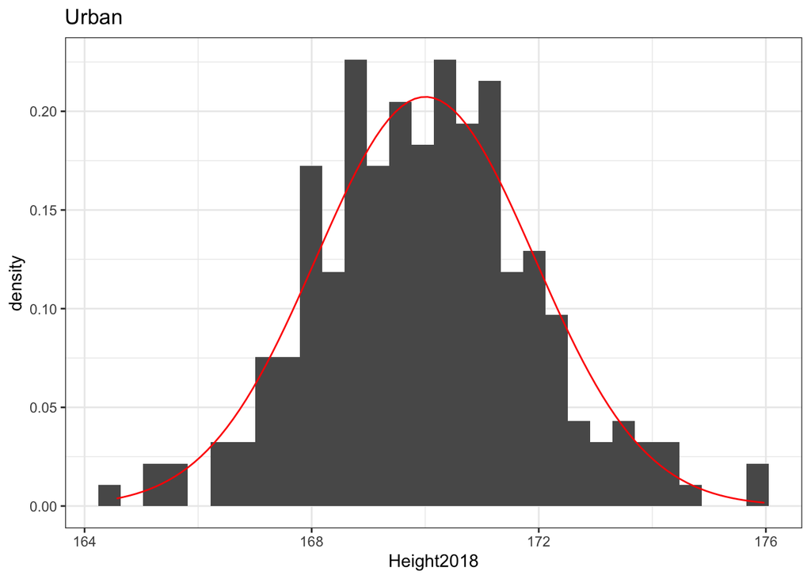

```
#Urban
ggplot(data = Rural,
       aes(x = Height2018)) +# We just need the arg x for the function aes() and histograms
    geom_histogram(aes(y = ..density..)) +# This line tells ggplot what king of graph we need. Also note that the function geom_histogram() also receive a function aes().
    theme_bw() + stat_function(fun=dnorm,
                         color="red",
                         args=list(mean=mean(Rural$Height2018),
                                  sd=sd(Rural$Height2018)))+
  ggtitle("Rural")
```

[figure not shown]

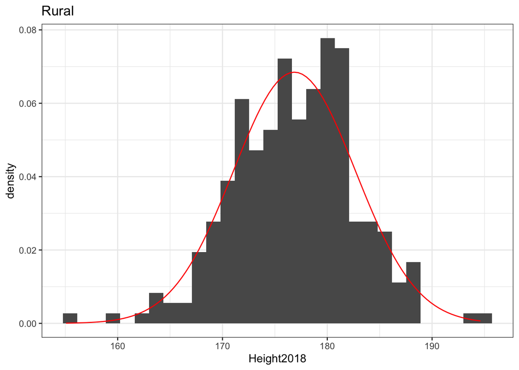

As we can see, the histograms are (more or less) normally distributed, so we should again use the independent samples t-test.

```
# We are first going to compute Levene's test

leveneTest(Height2018 ~ Area, data = dataset, center = mean)

# Now let's discuss the arguments of the function t.test# 'Height2018 ~ Area' indicates how R is going to split the data. Here we are looking at different height measures sampled (Height2014) according to two different areas (Area). We are going to discuss formulas in more detail later - on the linear models lecture.# 'data = dataset' works as data input to the function.# 'center = mean' indicates what kind of Levene's test we are performing. We chose mean as we are using it for a t.test - which is a test of means. Another option could be median.
```

| Property | Df<int> | F value<dbl> | Pr(>F)<dbl> |
| --- | --- | --- | --- |
| group | 1 | 166.1564 | 5.202507e-33 |
| Untitled | 498 | *NA* | *NA* |

The Levene’s test outcome suggests that there IS a statistically significant difference between the variances of both distributions. Hence we must perform our independent samples t-test considering that difference.

```
# We are now going to perform an independent samples t-test. There are a few different ways to do this. The simplest is probably as follows:

t.test(formula = Height2018 ~ Area, data = dataset, var.equal = FALSE)

# Now let's discuss the arguments of the function t.test# 'formula = Height2014 ~ Area' indicates how R is going to split the data. Here we are looking at different height measures sampled (Height2014) according to two different areas (Area). We are going to discuss formulas in more detail later - on the linear models lecture.# 'data = dataset' works as data input to the function.# 'var.equal = FALSE' tells R that we expect the variances of both distributions to be different.
```

```
##
##  Welch Two Sample t-test
##
## data:  Height2018 by Area
## t = -18.073, df = 325.67, p-value < 2.2e-16
## alternative hypothesis: true difference in means between group Urban and group Rural is not equal to 0
## 95 percent confidence interval:
##  -7.611638 -6.117200
## sample estimates:
## mean in group Urban mean in group Rural
##            170.0032            176.8677
```

The average height in 2018 was 170.0cm in urban areas and 176.9cm in rural areas. This difference was significant (t=-18.073, df=325.67, p<0.001; 95% CI: −7.61, −6.12; equal variances not assumed). Therefore, in 2018, the children who lived in rural areas were on average taller that those who lived in urban areas.

# **Task 6**

Use the appropriate test to see if there are statistically significant differences between the percentages of each ethnicity per area.

```
# First we look at the crosstables using the CrossTable() function from package 'gmodels'.

CrossTable(dataset$Ethnicity, dataset$Area,
           format=c("SPSS"),
           prop.r = FALSE,
           prop.t = FALSE,
           prop.chisq=FALSE)
```

```
##
##    Cell Contents
## |-------------------------|
## |                   Count |
## |          Column Percent |
## |-------------------------|
##
## Total Observations in Table:  500
##
##                   | dataset$Area
## dataset$Ethnicity |    Urban  |    Rural  | Row Total |
## ------------------|-----------|-----------|-----------|
##             White |      102  |      123  |      225  |
##                   |   43.220% |   46.591% |           |
## ------------------|-----------|-----------|-----------|
##             Black |       64  |       65  |      129  |
##                   |   27.119% |   24.621% |           |
## ------------------|-----------|-----------|-----------|
##             Asian |       47  |       56  |      103  |
##                   |   19.915% |   21.212% |           |
## ------------------|-----------|-----------|-----------|
##             Other |       23  |       20  |       43  |
##                   |    9.746% |    7.576% |           |
## ------------------|-----------|-----------|-----------|
##      Column Total |      236  |      264  |      500  |
##                   |   47.200% |   52.800% |           |
## ------------------|-----------|-----------|-----------|
##
##
```

```
# Now we perform a Chi-squared test in a similar fashion to the previous lecture. This time we shall use xtabs() function instead of table(), as it allows comparing multiple variables.

chisq.test(xtabs(formula = ~ Ethnicity + Area, data = dataset))
```

```
##
##  Pearson's Chi-squared test
##
## data:  xtabs(formula = ~Ethnicity + Area, data = dataset)
## X-squared = 1.3999, df = 3, p-value = 0.7056
```

There was no association between the ethnicity and area (Pearson’s chi-square = 1.400, df = 3, p = 0.706).

# Task 7

Use the appropriate test to see if there are statistically significant differences in quality of nutrition between 2014 and 2018.

The variables are categorical paired groups, so the appropriate test is the McNemar test.

```
# First we look at the crosstables using the CrossTable() function from package 'gmodels'.

CrossTable(dataset$Nutrition2014, dataset$Nutrition2018,
           format=c("SPSS"),
           prop.r = FALSE,
           prop.c = FALSE,
           prop.chisq=FALSE)
```

```
##
##    Cell Contents
## |-------------------------|
## |                   Count |
## |           Total Percent |
## |-------------------------|
##
## Total Observations in Table:  500
##
##                       | dataset$Nutrition2018
## dataset$Nutrition2014 |     poor  |  average  |     good  | Row Total |
## ----------------------|-----------|-----------|-----------|-----------|
##                  poor |       41  |       48  |       16  |      105  |
##                       |    8.200% |    9.600% |    3.200% |           |
## ----------------------|-----------|-----------|-----------|-----------|
##               average |       84  |      113  |       52  |      249  |
##                       |   16.800% |   22.600% |   10.400% |           |
## ----------------------|-----------|-----------|-----------|-----------|
##                  good |       33  |       79  |       34  |      146  |
##                       |    6.600% |   15.800% |    6.800% |           |
## ----------------------|-----------|-----------|-----------|-----------|
##          Column Total |      158  |      240  |      102  |      500  |
## ----------------------|-----------|-----------|-----------|-----------|
##
##
```

```
# Now we perform McNemar test by passing the two paired vectors (sliced from the tibble/dataframe) into the following function:

mcnemar.test(dataset$Nutrition2014, dataset$Nutrition2018)
```

```
##
##  McNemar's Chi-squared test
##
## data:  dataset$Nutrition2014 and dataset$Nutrition2018
## McNemar's chi-squared = 21.281, df = 3, p-value = 9.203e-05
```

The percentage of those who were characterised as having good nutrition in 2018 (20.4%) is lower than the corresponding in 2014 (29.2%). This difference was statistically significant according to the McNemar test (p < 0.001). Therefore, we conclude that the quality of nutrition decreased from 2014 to 2018.